# Introduction to Model Selection

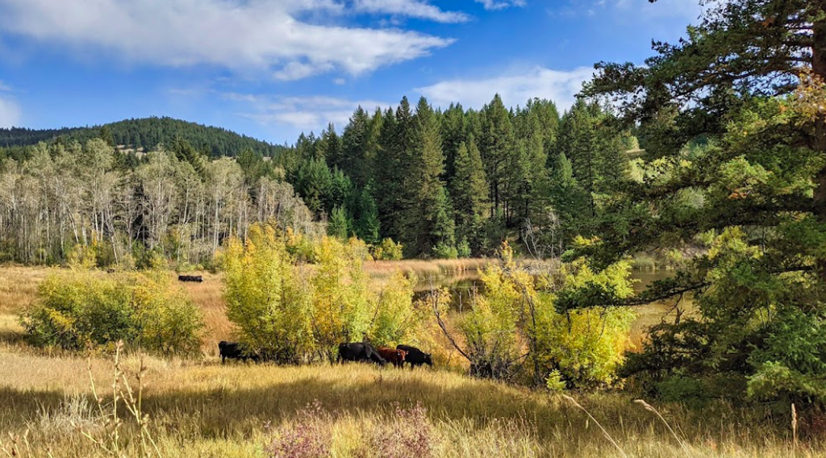

Dataset: Harrower, William L.; Srivastava, Diane S.; Turkington, Roy; Fraser, Lauchlan H. (2018), Data from: Temperate grassland songbird species accumulate incrementally along a gradient of primary productivity, Dryad, Dataset, https://doi.org/10.5061/dryad.365dr

## Background

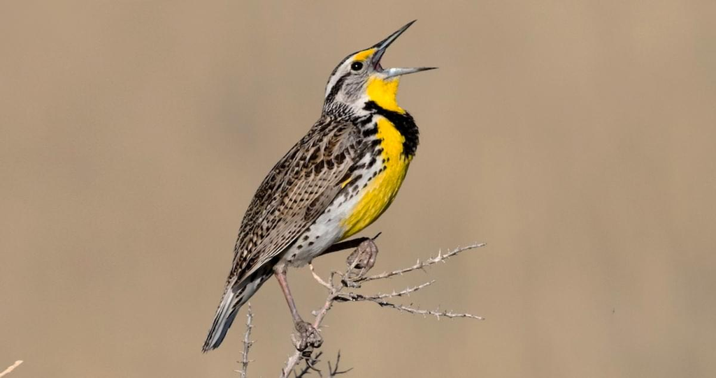

Goal is to find the more parsimonious model: aka simplest yet most accurate model. Easier to interpret and explain a simpler model than a complicated one.

One thing we want to watch out for more than co-linearity is multicolinearity. (washburn dataset)

VIF = Variance of Inflation / Tolerance

[figure not shown]

[figure not shown]

```r
grass<-read.csv("data/grass_data.csv")
```

**Multiple competing hypotheses**, with each hypothesis being represented in a separate model. 1. It does not rely on a single model. 2. Models can be ranked and weighted according to their fit to the observed data. 3. The best supported models can be averaged to get parameter estimates

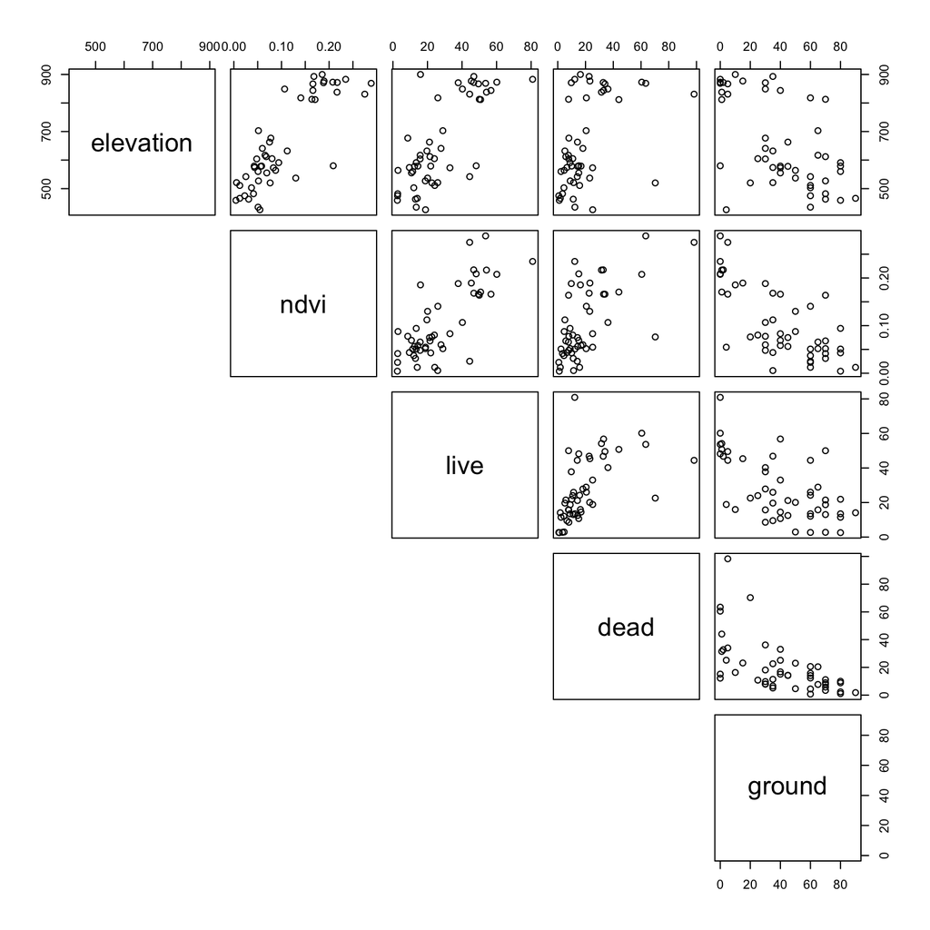

```r
#check for co-linearity among the four predictor variables
pairs(grass[,5:9], lower.panel = NULL) #use all rows of columns including predictor variables
```

Elevation and ndvi look closely related, and some of the others look fairly linear, which means they are very likely redundant information representing the same phenomenon. All of the combinations with percent ground cover look promising, so I’ll focus on that in my analysis.

```r
grassmodel <- lm(density ~ elevation + ndvi + live + dead + ground, data=grass)
anova (grassmodel) #coefficients of the full model
```

```
## Analysis of Variance Table
##
## Response: density
##           Df  Sum Sq Mean Sq F value  Pr(>F)
## elevation  1  159.20 159.202  4.6892 0.03595 *
## ndvi       1    9.61   9.610  0.2831 0.59744
## live       1   13.71  13.708  0.4038 0.52852
## dead       1   38.85  38.845  1.1442 0.29074
## ground     1   21.15  21.154  0.6231 0.43423
## Residuals 43 1459.89  33.951
## ---
## Signif. codes:  0 '***' 0.001 '**' 0.01 '*' 0.05 '.' 0.1 ' ' 1
```

Using the performance-collinearity check function, we can check our data for multicollinearity:

```r
performance::check_collinearity(grassmodel)
```

```
## # Check for Multicollinearity
##
## Low Correlation
##
##       Term  VIF Increased SE Tolerance
##  elevation 3.88         1.97      0.26
##       live 2.83         1.68      0.35
##       dead 1.82         1.35      0.55
##     ground 2.28         1.51      0.44
##
## Moderate Correlation
##
##  Term  VIF Increased SE Tolerance
##  ndvi 5.31         2.30      0.19
```

Four of the five predictors show a low correlation, while the fifth (ndvi) shows a moderate correlation. What this means is that the ndvi variable may have an interactive effect going on, whereas the other variables are more independent.

Next, I’m going to dredge the model to run all possible variable combinations. This helps decide which combos to run actual analysis on. All should add up to “1” (weight). I want to run my analysis on the models that have less than 2.0 model units from the top-rated model (delta 0.0). These ones have the most “competitive explanatory power”.

When model is dredged, it will show sum of weight and # containing models. Variables with more inclusions may be stronger/more likely to be included/have some kind of effect.

Pairwise comparison figures can help show the relationships between the different variables.

```r
options(na.action = "na.fail") # otherwise blows up with NA values
dredge_grass<-dredge(grassmodel)
dredge_grass
```

```
## Global model call: lm(formula = density ~ elevation + ndvi + live + dead + ground,
##     data = grass)
## ---
## Model selection table
##    (Intrc)     dead    elvtn    grond     live   ndvi df   logLik  AICc delta
## 3    5.964          0.011810                           3 -154.048 314.6  0.00
## 17  11.250                                     23.590  3 -154.177 314.9  0.26
## 18  11.470 -0.06748                            34.310  4 -153.356 315.6  0.99
## 4    5.242 -0.03806 0.014060                           4 -153.722 316.4  1.72
## 5   15.870                   -0.05391                  3 -154.958 316.4  1.82
## 7    8.286          0.009601 -0.02166                  4 -153.878 316.7  2.04
## 19   7.781          0.007295                   11.010  4 -153.895 316.7  2.07
## 11   5.136          0.014210          -0.02688         4 -153.969 316.8  2.22
## 25  11.480                            -0.02763 28.760  4 -154.098 317.1  2.48
## 21  12.180                   -0.01395          20.030  4 -154.124 317.2  2.53
```

[output cut: 56 more lines]

There are 32 possible models based on additive combinations of variables (no interaction terms).

I’m going to subset these model and isolate the top competitive model combinations:

```r
#grab equally competitive models
subset(dredge_grass, delta <2)
```

```
## Global model call: lm(formula = density ~ elevation + ndvi + live + dead + ground,
##     data = grass)
## ---
## Model selection table
##    (Intrc)     dead   elvtn    grond  ndvi df   logLik  AICc delta weight
## 3    5.964          0.01181                 3 -154.048 314.6  0.00  0.302
## 17  11.250                           23.59  3 -154.177 314.9  0.26  0.265
## 18  11.470 -0.06748                  34.31  4 -153.356 315.6  0.99  0.184
## 4    5.242 -0.03806 0.01406                 4 -153.722 316.4  1.72  0.128
## 5   15.870                  -0.05391        3 -154.958 316.4  1.82  0.121
## Models ranked by AICc(x)
```

There are five models that could be considered equally competitive (having explanatory power that is indistinguishable). Checking to see which variables are most influential:

```r
importance(dredge_grass)
```

```
##                      elevation ndvi dead ground live
## Sum of weights:      0.47      0.47 0.35 0.32   0.26
## N containing models:   16        16   16   16     16
```

Elevation and ndvi are equally ranked with having the highest explanatory power, but percent dead vegetation and percent ground cover are also fairly close. Percent live vegetation is a bit lower, but still now very much lower.

Just taking a look at each predictor variable against the response variable (density):

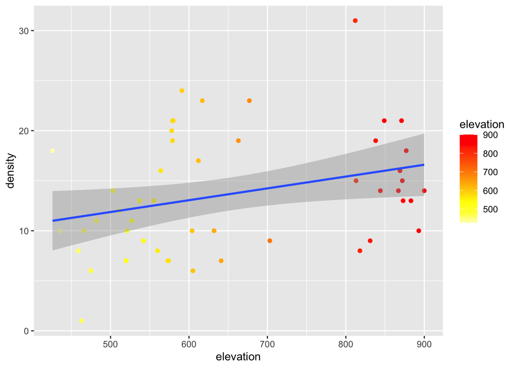

```r
g1 <- ggplot(grassmodel, aes(elevation, density, color = elevation)) +
  geom_point() +
  geom_smooth(method="lm") +
  scale_colour_gradientn(colors = heat.colors(10, rev=TRUE))

g2 <- ggplot(grassmodel, aes(ndvi, density, color = ndvi)) +
  geom_point() +
  geom_smooth(method="lm") +
  scale_colour_gradientn(colors = terrain.colors(10, rev=TRUE))

g3 <- ggplot(grassmodel, aes(live, density)) +
  geom_point() +
  geom_smooth(method="lm")

g4 <- ggplot(grassmodel, aes(dead, density)) +
  geom_point() +
  geom_smooth(method="lm")

g5 <- ggplot(grassmodel, aes(ground, density)) +
  geom_point() +
  geom_smooth(method="lm")

g1
```

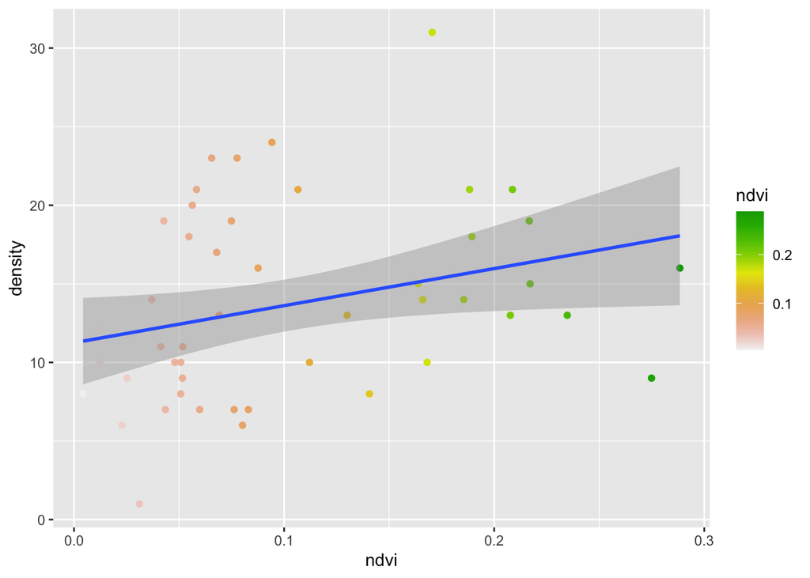

```r
g2
```

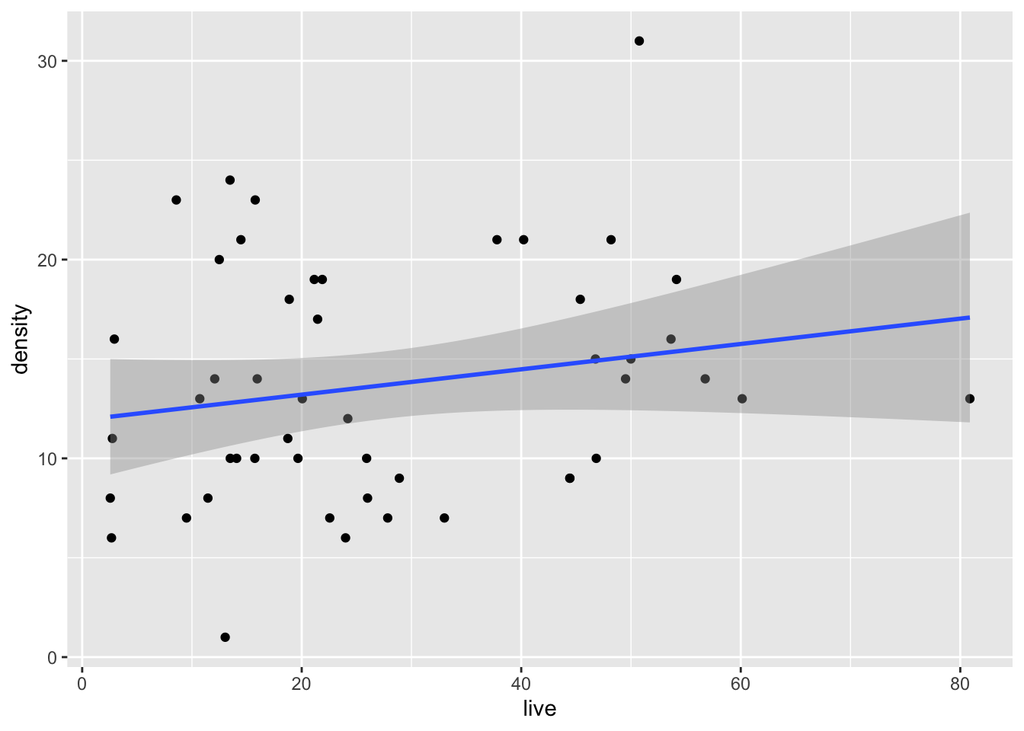

```r
g3
```

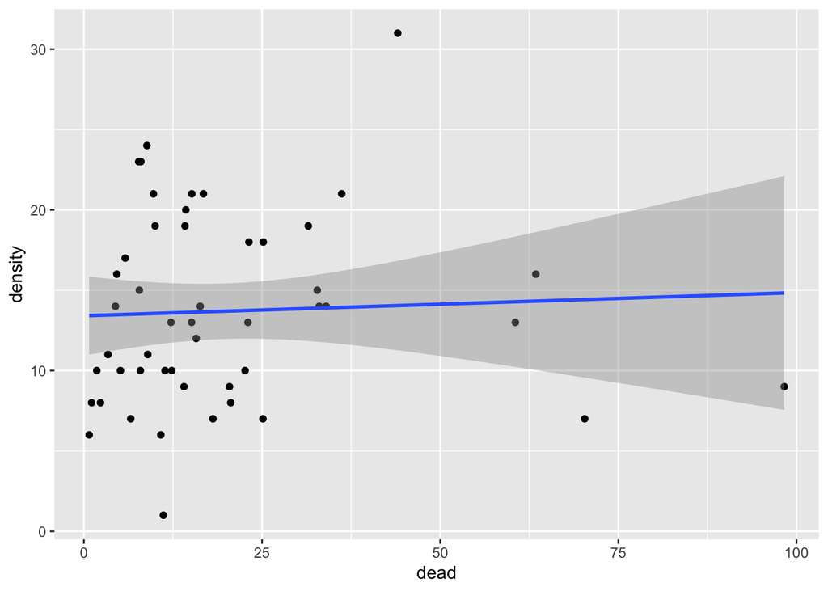

```r
g4
```

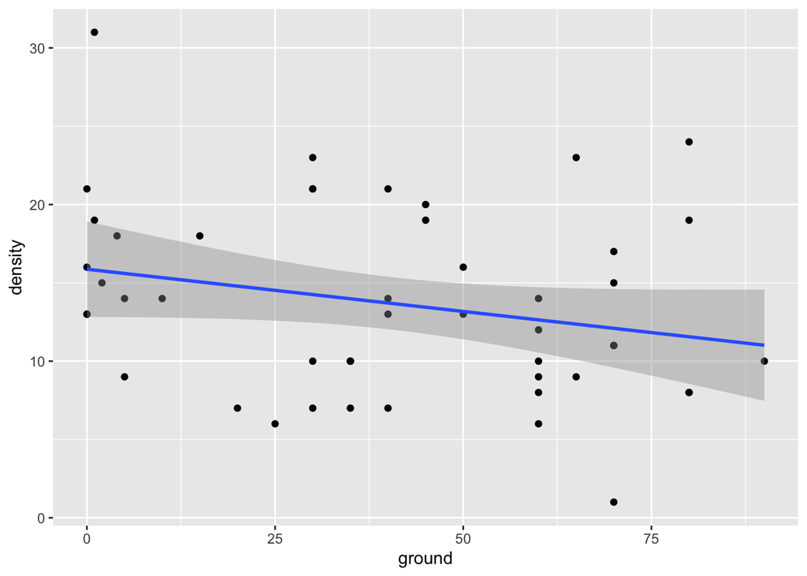

```r
g5
```

Based on these top 5 candidate models, I can now run my linear models including these individual and additive variables.

I’ll fit the candidate models that will likely best explain any variation in grassland bird density. Ideally, these models would represent hypotheses. Given the nature of the response, we’ll use ordinary linear regression with the `lm` function.

```r
#First, fit 4 candidate linear models to explain variation in density
mod1<-lm(density~elevation, data = grass)
mod2<-lm(density~ndvi, data = grass)
mod3<-lm(density~ndvi+dead, data = grass)
mod4<-lm(density~elevation+dead, data = grass)
mod5<-lm(density~ground, data = grass)
```

We can now use the `model.sel` function to conduct model selection. The default model selection criteria is Akaike’s information criteria (AIC) with small sample bias adjustment, AIC<sub>c</sub>. Here we’ll create an object `out.put` that contains all of the model selection information.

```r
# use the model.sel function to conduct model selection
out.put<-model.sel(mod1,mod2,mod3,mod4,mod5)
out.put
```

```
## Model selection table
##      (Intrc)   elvtn  ndvi     dead    grond             family df   logLik
## mod1   5.964 0.01181                         gaussian(identity)  3 -154.048
## mod2  11.250         23.59                   gaussian(identity)  3 -154.177
## mod3  11.470         34.31 -0.06748          gaussian(identity)  4 -153.356
## mod4   5.242 0.01406       -0.03806          gaussian(identity)  4 -153.722
## mod5  15.870                        -0.05391 gaussian(identity)  3 -154.958
##       AICc delta weight
## mod1 314.6  0.00  0.302
## mod2 314.9  0.26  0.265
## mod3 315.6  0.99  0.184
## mod4 316.4  1.72  0.128
## mod5 316.4  1.82  0.121
## Models ranked by AICc(x)
```

```r
# select models using Royall's 1/8 rule for strength of evidence
#https://www.stat.fi/isi99/proceedings/arkisto/varasto/roya0578.pdf
# IMPORTANT: Weights have been renormalized!!
subset(out.put, 1/8 < weight/max(out.put$weight))
```

```
## Model selection table
##      (Intrc)   elvtn  ndvi     dead    grond             family df   logLik
## mod1   5.964 0.01181                         gaussian(identity)  3 -154.048
## mod2  11.250         23.59                   gaussian(identity)  3 -154.177
## mod3  11.470         34.31 -0.06748          gaussian(identity)  4 -153.356
## mod4   5.242 0.01406       -0.03806          gaussian(identity)  4 -153.722
## mod5  15.870                        -0.05391 gaussian(identity)  3 -154.958
##       AICc delta weight
## mod1 314.6  0.00  0.302
## mod2 314.9  0.26  0.265
## mod3 315.6  0.99  0.184
## mod4 316.4  1.72  0.128
## mod5 316.4  1.82  0.121
## Models ranked by AICc(x)
```

```r
# select models 95% cumulative weight criteria
# IMPORTANT: Weights have been renormalized!!
subset(out.put, cumsum(out.put$weight) <= .95)
```

```
## Model selection table
##      (Intrc)   elvtn  ndvi     dead             family df   logLik  AICc delta
## mod1   5.964 0.01181                gaussian(identity)  3 -154.048 314.6  0.00
## mod2  11.250         23.59          gaussian(identity)  3 -154.177 314.9  0.26
## mod3  11.470         34.31 -0.06748 gaussian(identity)  4 -153.356 315.6  0.99
## mod4   5.242 0.01406       -0.03806 gaussian(identity)  4 -153.722 316.4  1.72
##      weight
## mod1  0.344
## mod2  0.302
## mod3  0.209
## mod4  0.145
## Models ranked by AICc(x)
```

```r
# coerce the object out.put into a data frame
# elements 6-10 in out.put have what we want
sel.table<-as.data.frame(out.put)[6:10]
sel.table
```

```
##                  family df    logLik     AICc     delta
## mod1 gaussian(identity)  3 -154.0480 314.6294 0.0000000
## mod2 gaussian(identity)  3 -154.1767 314.8867 0.2573429
## mod3 gaussian(identity)  4 -153.3560 315.6211 0.9916777
## mod4 gaussian(identity)  4 -153.7218 316.3527 1.7232921
## mod5 gaussian(identity)  3 -154.9582 316.4498 1.8203993
```

```r
# how about a little renaming columns to fit proper conventions
# number of parameters (df) should be K
names(sel.table)[1] = "K"

## lets be sure to put the model names in a column
sel.table$Model<-rownames(sel.table)

# let's see what is in there
sel.table
```

```
##                       K df    logLik     AICc     delta Model
## mod1 gaussian(identity)  3 -154.0480 314.6294 0.0000000  mod1
## mod2 gaussian(identity)  3 -154.1767 314.8867 0.2573429  mod2
## mod3 gaussian(identity)  4 -153.3560 315.6211 0.9916777  mod3
## mod4 gaussian(identity)  4 -153.7218 316.3527 1.7232921  mod4
## mod5 gaussian(identity)  3 -154.9582 316.4498 1.8203993  mod5
```

```r
#little reordering of columns
sel.table<-sel.table[,c(6,1,2,3,4,5)] #specify order of columns
sel.table
```

```
##      Model                  K df    logLik     AICc     delta
## mod1  mod1 gaussian(identity)  3 -154.0480 314.6294 0.0000000
## mod2  mod2 gaussian(identity)  3 -154.1767 314.8867 0.2573429
## mod3  mod3 gaussian(identity)  4 -153.3560 315.6211 0.9916777
## mod4  mod4 gaussian(identity)  4 -153.7218 316.3527 1.7232921
## mod5  mod5 gaussian(identity)  3 -154.9582 316.4498 1.8203993
```

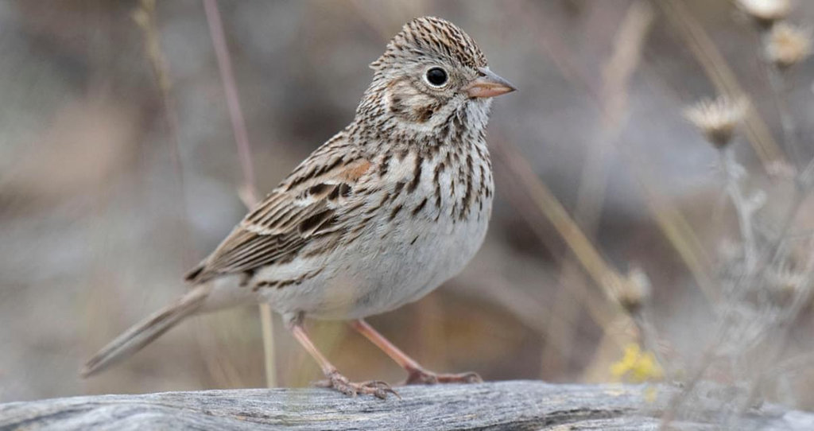

## Caveats and Limitations to Model Selection

1. Depends on the models included in the candidate set. You can’t identify a model as being the “best” fit to the data if you didn’t include the model to begin with!
2. The parameter estimates and predictions arising from the “best” model or set of best models should be biologically meaningful.
3. Need to decide whether to use model selection or common inferential statistics (e.g. based on P-values). Techniques that rely on both approaches are possible (e.g. backward variable selection followed by averaging of top models) but are discouraged by some model-selection purists.
4. Difficult or impossible to compare models with different assumptions, such as those with different error structures (e.g., Poisson vs. Binomial data).